# Explore normal cell types in Neuroblastoma samples

Stephanie J. Spielman

2025-07-03

## Introduction

The goal of this notebook is to explore the distribution of normal consensus cell types, specifically immune and endothelial, in the Neuroblastoma tumor (i.e., *not* the PDX) samples from `SCPCP000004`.

Based on these findings, we can determine approaches to evaluate for pooling cells to use as a normal reference for `inferCNV`. We can also determine whether any samples can be run with an internal (non-pooled) reference as a control.

## Setup

```r
options(readr.show_col_types = FALSE)
suppressPackageStartupMessages({
  library(ggplot2)
  library(SingleCellExperiment)
})
```

```
G2;H2;Warningh: package ‘GenomicRanges’ was built under R version 4.4.1g
G2;H2;Warningh: package ‘S4Vectors’ was built under R version 4.4.1g
G2;H2;Warningh: package ‘IRanges’ was built under R version 4.4.1g
```

```r
theme_set(theme_bw())
```

### Paths

#### Base directories

```r
# The base path for the OpenScPCA repository, found by its (hidden) .git directory
repository_base <- rprojroot::find_root(rprojroot::is_git_root)

# The current data directory, found within the repository base directory
data_dir <- file.path(repository_base, "data", "current", "SCPCP000004")

# Path to reference cell type groupings
reference_dir <- file.path(repository_base, "analyses", "infercnv-consensus-cell-type", "references")
```

#### Input and output files

```r
# Input sce files to get consensus cell types
sce_files <- list.files(
  path = data_dir,
  pattern = "_processed\\.rds$",
  recursive = TRUE,
  full.names = TRUE
) |>
  # set names as library id
  purrr::set_names(
    \(x) {
      stringr::str_split_i(basename(x), "_", 1)
    }
  )

# project sample metadata file
metadata_file <- file.path(data_dir, "single_cell_metadata.tsv")

# reference cell type groups
reference_file <- file.path(reference_dir, "reference-cell-groups.tsv")
```

## Analysis

```r
# determine PDX libraries to exclude
tumor_library_ids <- readr::read_tsv(metadata_file) |>
  dplyr::filter(!is_xenograft) |>
  dplyr::pull(scpca_library_id)

# get cell groups
cell_group_df <- readr::read_tsv(reference_file)

# Prepare data frame of all cell types
celltype_df <- sce_files |>
  # consider only non-PDX
  purrr::keep_at(tumor_library_ids) |>
  purrr::map(
    \(sce_file) {
      readRDS(sce_file) |>
        colData() |>
        as.data.frame() |>
        dplyr::select(
          barcodes,
          consensus_annotation = consensus_celltype_annotation
        )
  }) |>
  purrr::list_rbind(names_to = "library_id") |>
  dplyr::left_join(cell_group_df, by = "consensus_annotation")
```

We’ll first exclude any libraries that have fewer than 1000 cells from consideration in the reference.

```r
discard_libraries <- celltype_df |>
  dplyr::count(library_id) |>
  dplyr::filter(n < 1000) |>
  dplyr::pull(library_id)

discard_libraries
```

```
[1] "SCPCL000118" "SCPCL000120" "SCPCL000124" "SCPCL001065"
```

```r
celltype_df <- celltype_df |>
  dplyr::filter(!(library_id %in% discard_libraries))
```

These cell groupings are present in the neuroblastoma samples we’re considering:

```r
unique(celltype_df$reference_cell_group)
```

```
[1] NA            "stromal"     "immune"      "endothelial" "neuronal"    "adipocyte"   "epithelial"
```

We should remove any cell groups which might correspond to tumor cells, including `stromal`, `neuronal`, and `stem cell`. The `NA` values here correspond to `Unknown` cells, which we’ll also remove. This means we’ll keep groups `endothelial`, `epithelial`, `adipocyte`, and `immune`.

```r
# First, we want to count the total number of cells to use for later plotting
total_cells_df <- celltype_df |>
  dplyr::count(library_id, name = "total_cells")

# Now we can remove unwanted cells
exclude_groups <- c("stromal", "neuronal", "stem cell")
celltype_df <- celltype_df |>
  dplyr::filter(
    !(reference_cell_group %in% exclude_groups),
    consensus_annotation != "Unknown"
  )
```

Let’s begin by counting how many cells in each cell group we have per library.

```r
celltype_count_df <- celltype_df |>
  dplyr::count(library_id, reference_cell_group)

# format for viewing
celltype_count_wide_df <- celltype_count_df |>
  tidyr::pivot_wider(
    names_from = reference_cell_group,
    values_from = n,
    values_fill = 0
  ) |>
  # add column for total normal cells
  dplyr::mutate(
    all_normal = rowSums(dplyr::across(where(is.numeric)))
  ) |>
  # arrange by total normal cells
  dplyr::arrange(desc(all_normal))

# this way we can print the full table at once; RMarkdown will only show 10 rows at once
knitr::kable(celltype_count_wide_df)
```

[output not shown]

| library_id | endothelial | immune | adipocyte | epithelial | all_normal |
| --- | --- | --- | --- | --- | --- |
| SCPCL000127 | 184 | 2688 | 0 | 0 | 2872 |
| SCPCL000126 | 194 | 2589 | 0 | 0 | 2783 |
| SCPCL000125 | 810 | 690 | 0 | 0 | 1500 |
| SCPCL000122 | 7 | 925 | 2 | 1 | 935 |
| SCPCL000132 | 175 | 646 | 0 | 0 | 821 |
| SCPCL000133 | 126 | 662 | 0 | 0 | 788 |
| SCPCL000128 | 340 | 446 | 0 | 0 | 786 |
| SCPCL000141 | 271 | 262 | 0 | 0 | 533 |
| SCPCL000140 | 220 | 213 | 51 | 0 | 484 |
| SCPCL000135 | 67 | 404 | 0 | 0 | 471 |
| SCPCL000134 | 0 | 428 | 0 | 0 | 428 |
| SCPCL000138 | 37 | 336 | 0 | 0 | 373 |
| SCPCL000129 | 231 | 126 | 0 | 0 | 357 |
| SCPCL000136 | 64 | 231 | 0 | 0 | 295 |
| SCPCL000139 | 134 | 110 | 3 | 0 | 247 |
| SCPCL000130 | 30 | 160 | 0 | 0 | 190 |
| SCPCL000142 | 22 | 155 | 0 | 0 | 177 |
| SCPCL000123 | 30 | 144 | 0 | 0 | 174 |
| SCPCL000121 | 88 | 30 | 1 | 0 | 119 |
| SCPCL000131 | 42 | 42 | 0 | 0 | 84 |
| SCPCL000119 | 36 | 45 | 0 | 0 | 81 |
| SCPCL000137 | 8 | 24 | 0 | 0 | 32 |

Virtually all of the normal cell types are `endothelial` and `immune`, with very few `adipocyte` and literally only one `epithelial` cell.

We’ll look at this data in barplot form to see, per-library, the relative proportions of each normal cell type group out of *all cells* in the library. The height of each bar is the total fraction of normal cells in that library to begin with; note the Y-axis only ranges from around `[0,0.3]`.

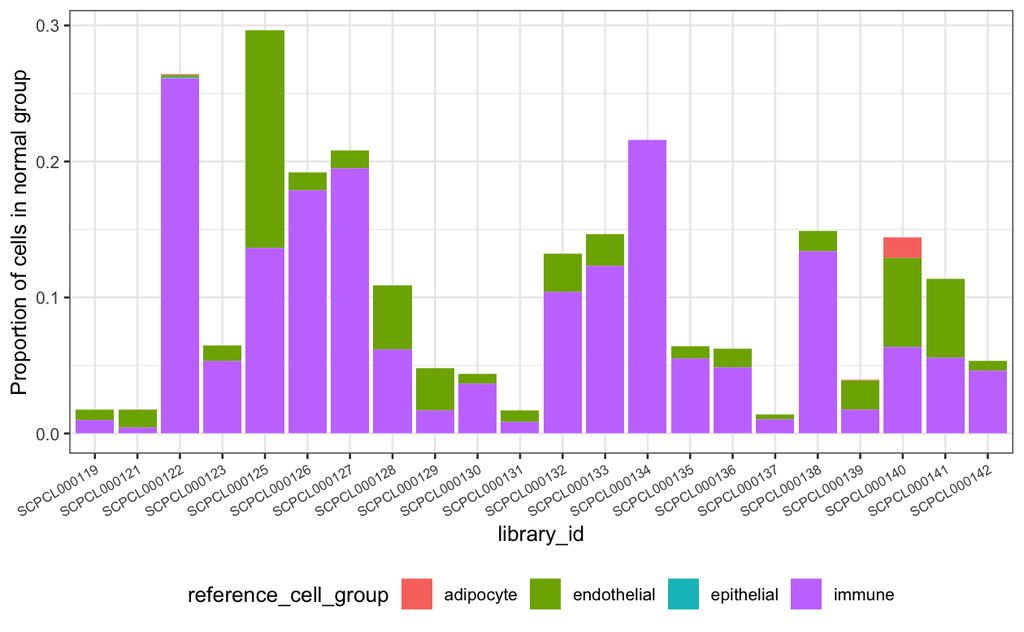

```r
celltype_prop_df <- celltype_count_wide_df |>
  dplyr::select(-all_normal) |>
  # long again, but keep all_normal column for calculating proportion
  tidyr::pivot_longer(
    -library_id,
    names_to = "reference_cell_group",
    values_to = "n"
  ) |>
  dplyr::left_join(total_cells_df) |>
  dplyr::mutate(cell_group_prop = n / total_cells)
ggplot(celltype_prop_df) +
  aes(x = library_id, y = cell_group_prop, fill = reference_cell_group) +
  geom_col() +
  labs(y = "Proportion of cells in normal group") +
  theme(
    legend.position = "bottom",
    axis.text.x = element_text(angle = 30, hjust = 1, size = 7)
  )
```

Based on these numbers, we can consider three normal reference options:

- All normal cells
- All immune cells
- All endothelial cells

How many cells would be in each of those pooled references?

```r
# update the count data frame without categories we don't need.
# note that this does not remove adipocyte or epithelial counts from the `all_normal` group; it just
# removes them as standalone categories
celltype_count_df <- celltype_count_wide_df |>
  dplyr::select(-adipocyte, -epithelial) |>
  tidyr::pivot_longer(
    -library_id,
    names_to = "reference_cell_group",
    values_to = "n"
  )

celltype_count_df |>
  dplyr::group_by(reference_cell_group) |>
  dplyr::summarize(total_cells = sum(n))
```

| reference_cell_group | total_cells |
| --- | --- |
| all_normal | 14530 |
| endothelial | 3116 |
| immune | 11356 |

Well, that’s quite a lot of cells for these pooled references! A potential concern is that this many cells will incur prohibitive runtimes, so we may want to explore a subsampling strategy. Any subsampling strategy should aim to retain the relative cell type proportions across libraries, but we can explore that if runtime becomes a problem when we reach that stage.

Finally, let’s see which libraries could have an internal reference. `inferCNV` recommends at least 100 cells in a reference, so which combinations of library/reference are possible here?

```r
celltype_count_df |>
  dplyr::filter(n >= 100) |>
  dplyr::group_by(library_id) |>
  dplyr::mutate(reference_options = paste(reference_cell_group, collapse = ", ")) |>
  dplyr::ungroup() |>
  dplyr::select(library_id, reference_options) |>
  unique() |>
  # add row counter so we can easily see how many libraries
  dplyr::mutate(row_num = dplyr::row_number()) |>
  # kable to print the full table at once
  knitr::kable()
```

| library_id | reference_options | row_num |
| --- | --- | --- |
| SCPCL000127 | endothelial, immune, all_normal | 1 |
| SCPCL000126 | endothelial, immune, all_normal | 2 |
| SCPCL000125 | endothelial, immune, all_normal | 3 |
| SCPCL000122 | immune, all_normal | 4 |
| SCPCL000132 | endothelial, immune, all_normal | 5 |
| SCPCL000133 | endothelial, immune, all_normal | 6 |
| SCPCL000128 | endothelial, immune, all_normal | 7 |
| SCPCL000141 | endothelial, immune, all_normal | 8 |
| SCPCL000140 | endothelial, immune, all_normal | 9 |
| SCPCL000135 | immune, all_normal | 10 |
| SCPCL000134 | immune, all_normal | 11 |
| SCPCL000138 | immune, all_normal | 12 |
| SCPCL000129 | endothelial, immune, all_normal | 13 |
| SCPCL000136 | immune, all_normal | 14 |
| SCPCL000139 | endothelial, immune, all_normal | 15 |
| SCPCL000130 | immune, all_normal | 16 |
| SCPCL000142 | immune, all_normal | 17 |
| SCPCL000123 | immune, all_normal | 18 |
| SCPCL000121 | all_normal | 19 |

## Conclusions

- To start, we can consider three references: all normal, all immune, and possibly also all endothelial
  - We may need to consider a subsetting strategy for these references if runtimes are too long since there would be >10,000 cells in the immune-containing pooled normal references
- There are 19 libraries we can use internal references with, all with the option for all normal cells and some with the immune-only or endothelial-only options too